# Machine Learning Course Project

John Sullivan

May 7, 2018

## Summary

Using the barbell weight lifting dataset that contains accelerometer data from the quantified self movement, the goal was to build a model that would accurately predict if the barbell lifts were done correctly or incorrectly in 5 different ways. Information on this web side can be found here: http://web.archive.org/web/20161224072740/http:/groupware.les.inf.puc-rio.br/har

I decided to get fancy for this final assignment, and decided to build an ensemble model using various machine learning algorithms as found in the CARAT package to predict the ‘classe’ variable using the various accelerometer data. I specifically removed the test subjects from the build to improve model usablitity.

### Step 1 - Load the Libraries

```r
# Get our Parallel going on
library(doParallel)
registerDoParallel(cores=4)

# Define libaries for fast 'n' easy data manipulation in Data Tables
library(R.utils)
library(data.table)
library(dplyr)
library(janitor)

# Analytical Model Building
library(AppliedPredictiveModeling)
library(caret)
```

```r
library(ggplot2)
library(MASS)
library(randomForest)
library(gbm)
```

### Step 2 - Download the data and clean it up

```r
# Check for the pml data, if it doesn't exist, download and read it in
if (!exists('pml_training_input')) {

    # Download and unzip the file if needed
    if (!file.exists("./pml-testing.csv"))  {
        download.file('https://d396qusza40orc.cloudfront.net/predmachlearn/pml-testing.csv'
                      , dest="./pml-testing.csv", mode = "wb")
    }
    if (!file.exists("./pml-training.csv"))  {
        download.file('https://d396qusza40orc.cloudfront.net/predmachlearn/pml-training.csv'
                      , dest="./pml-training.csv", mode = "wb")
    }

    # Read in the data table
    pml_training_input <- fread("./pml-training.csv")
    pml_testing_input <- fread("./pml-testing.csv")
}

# Clean-up the training set to remove the non-applicable new_window=="yes" as well
#  as get rid of a lot of now empty/useless columns

pml_training <- filter(pml_training_input, new_window=="no" ) %>%
                mutate_all(funs(na_if(., ""))) %>%
                remove_empty("cols")

pml_testing <- filter(pml_testing_input, new_window=="no" ) %>%
                mutate_all(funs(na_if(., ""))) %>%
                remove_empty("cols")
rm(list=c("pml_training_input","pml_testing_input"))

# To make the training and testing datasets consistent, convert all the integers
#  in the independent variables to numerics.
pml_training[,8:59] <- lapply(pml_training[,8:59,drop=FALSE],as.numeric)
pml_testing[,8:59] <- lapply(pml_testing[,8:59,drop=FALSE],as.numeric)

# Drop the first seven columns.  Sure, the name might be helpful, but that's kind of
# cheating.  Drop the timestamps, though.

pml_training <- pml_training[,8:60]
pml_training$classe <- as.factor(pml_training$classe)
pml_testing <- pml_testing[,8:60]
```

### Step 3 - Split up the training data set

I split the assignment training dataset itself into three populations - 56% to train the individual algorithms, 24% for training the ensemble, and the remaining 20% of the data for testing model performance. Then, I checked how many data points was left in each of the sets.

```r
# Create training, testing, and validation data sets
inBuild <- createDataPartition(y=pml_training$classe,p=0.8, list=FALSE)
etest <- pml_training[-inBuild,];
ebuild <- pml_training[inBuild,]
inTrain <- createDataPartition(y=ebuild$classe,p=0.7, list=FALSE)
etrain <- ebuild[-inTrain,];
btrain <- ebuild[inTrain,]
# Check data point counts;
dim(btrain); dim(etrain); dim(etest)
```

```
## [1] 10765    53
```

```
## [1] 4610   53
```

```
## [1] 3841   53
```

### Step 4 - Train the individual algorithms

I tried a number of different algorithms as available in CARET (more variety is better in an ensemble, correct?) and found some to be more effective than others.

Final algorithms I selected included: - K-nearest Neighbors (this one seems like it might be directly applicable to the problem) - Random Forest (a go-to that works well on many problems and an emsemble model in it’s own right) - Linear Discriminant (LDA flavor was better than SLDA or HDDA) - Extreme Learning Neural (better than other neural flavors I tried, but not really that good in this application) - GBM Stochastic Gradient Boosting - Support Vector Machine

I also tried a Naive Bayes algorithm, but couldn’t get it to work so threw it out.

I used 5-fold cross validation as it seemed the minimum that would work well and more folds took ridiculous amounts of time to execute. Likely much more tuning could have been done for the various computation methods, but I was interested to see how the various algorithms would perform against each other using mostly stock settings. The cross validation helped to improve the quality of the individual algorithm results.

```r
# Build some models on base train set - pick some favorites from internet
set.seed(75007)

# K-nearest Neighbors
ptm <- proc.time()
modKC <- train(classe ~.,method="knn",data=btrain,
               trControl = trainControl(method="cv",number=5))
ptmKC <- proc.time() - ptm

# Random Forest
ptm <- proc.time()
modRF <- train(classe ~.,method="rf", data=btrain,
               trControl = trainControl(method="cv",number=5))
ptmRF <- proc.time() - ptm

# Linear Discriminate
ptm <- proc.time()
modLDA <- train(classe ~.,method="lda",data=btrain)
ptmLDA <- proc.time() - ptm

# ELM (Extreme Learning Machine) Neural
ptm <- proc.time()
modELM<- train(classe ~.,method="elm", data=btrain,
               trControl=trainControl(method='cv',number=5),
               tuneGrid =expand.grid(.nhid=53,.actfun=c("sin","radbas","purelin","tansig")))
ptmELM <- proc.time() - ptm


# GBM Stochastic Gradient Boosting
ptm <- proc.time()
modGBM <- train(classe ~.,method = "gbm", data=btrain,
                trControl=trainControl(method='cv',number=5),
                verbose=F)
ptmGBM <- proc.time() - ptm


# Support Vector Machine
ptm <- proc.time()
modSVM <- train(classe ~.,method="svmLinear",data=btrain, preProc = c("center","scale"),
                trControl=trainControl(method="cv",number=5))
ptmSVM <- proc.time() - ptm
```

### Step 5 - Build the Ensemble

To do this, score the individual models on the ensemble training set, and then build the ensemble on their results using GBM.

```r
# Score individual models on the etrain dataset and create the stack for the ensemble model.
# Use the probability for each class where that is the model output, and for those where only a single class is predicted (ELM & SVM), set probabilities

predKC <- predict(modKC, newdata=etrain, type="prob")
predRF <- predict(modRF, newdata=etrain, type="prob")
predLDA <- predict(modLDA, newdata=etrain, type="prob")
predELM_cls <- predict(modELM, newdata=etrain)
predELM <- data.frame(A=as.numeric(predELM_cls=="A"),
                      B=as.numeric(predELM_cls=="B"),
                      C=as.numeric(predELM_cls=="C"),
                      D=as.numeric(predELM_cls=="D"),
                      E=as.numeric(predELM_cls=="E"))
predGBM <- predict(modGBM, newdata = etrain, type="prob")
predSVM_cls <- predict(modSVM, newdata = etrain)
predSVM <- data.frame(A=as.numeric(predSVM_cls=="A"),
                      B=as.numeric(predSVM_cls=="B"),
                      C=as.numeric(predSVM_cls=="C"),
                      D=as.numeric(predSVM_cls=="D"),
                      E=as.numeric(predSVM_cls=="E"))
predGBM <- predict(modGBM, newdata = etrain, type="prob")


etrain_STK <- data.frame(KC=predKC, RF=predRF, LDA=predLDA,
                         ELM=predELM, GBM=predGBM, SVM=predSVM,
            classe = etrain$classe, stringsAsFactors = T)

# Stack the uber ensemble with GBM

ptm <- proc.time()
modSTK <- train(classe ~., data = etrain_STK, method = "gbm",
                trControl=trainControl(method="cv", number=5),
                tuneLength=3)
ptmDF<- proc.time() - ptm
```

### Step 6 - Get the accuracy of the models

```r
# Predict on the etest dataset, not the etrain.

predKC_tst <- predict(modKC, newdata=etest,type='prob')
predRF_tst <- predict(modRF, newdata=etest,type='prob')
predLDA_tst <- predict(modLDA, newdata=etest,type='prob')
predELM_tst_cls <- predict(modELM, newdata=etest)
predELM_tst <- data.frame(A=as.numeric(predELM_tst_cls=="A"),
                      B=as.numeric(predELM_tst_cls=="B"),
                      C=as.numeric(predELM_tst_cls=="C"),
                      D=as.numeric(predELM_tst_cls=="D"),
                      E=as.numeric(predELM_tst_cls=="E"))
predGBM_tst <- predict(modGBM, newdata = etest,type='prob')
predSVM_tst_cls <- predict(modSVM, newdata = etest)
predSVM_tst <- data.frame(A=as.numeric(predSVM_tst_cls=="A"),
                      B=as.numeric(predSVM_tst_cls=="B"),
                      C=as.numeric(predSVM_tst_cls=="C"),
                      D=as.numeric(predSVM_tst_cls=="D"),
                      E=as.numeric(predSVM_tst_cls=="E"))
etest_stk <- data.frame(KC=predKC_tst,
                        RF=predRF_tst,
                        LDA=predLDA_tst,
                        ELM=predELM_tst,
                        GBM=predGBM_tst,
                        SVM=predSVM_tst,
                     classe = etest$classe, stringsAsFactors = T)
predSTK_tst <- predict(modSTK, newdata = etest_stk)

cm_KC <- confusionMatrix(predict(modKC, newdata=etest), etest$classe)
cm_RF <- confusionMatrix(predict(modRF, newdata=etest), etest$classe)
cm_LDA <- confusionMatrix(predict(modLDA, newdata=etest), etest$classe)
cm_ELM <- confusionMatrix(predict(modELM, newdata=etest), etest$classe)
cm_GBM <- confusionMatrix(predict(modGBM, newdata=etest), etest$classe)
cm_SVM <- confusionMatrix(predict(modSVM, newdata=etest), etest$classe)
cm_STK <- confusionMatrix(predSTK_tst, etest$classe)

# Build Results table with accuracy, kappa, and run time
model_type <- c('knn','rf','lda','elm','gbm','svmLinear','stack-gbm')
run_time <-c(ptmKC[3],ptmRF[3],ptmLDA[3],ptmELM[3],
             ptmGBM[3],ptmSVM[3],(ptmDF[3]+ptmKC[3]+ptmRF[3]+ptmLDA[3]+ptmELM[3]+
                                  ptmGBM[3]+ptmSVM[3]))
m_accuracy <- c(cm_KC$overall[1],
                cm_RF$overall[1],
                cm_LDA$overall[1],
                cm_ELM$overall[1],
                cm_GBM$overall[1],
                cm_SVM$overall[1],
                cm_STK$overall[1]
                )
m_kappa <- c(cm_KC$overall[2],
             cm_RF$overall[2],
             cm_LDA$overall[2],
             cm_ELM$overall[2],
             cm_GBM$overall[2],
             cm_SVM$overall[2],
             cm_STK$overall[2]
)
m_comparisons <- data.frame(model_type,run_time,m_accuracy,m_kappa)

m_comparisons
```

```
##   model_type run_time m_accuracy   m_kappa
## 1        knn    43.72  0.8919552 0.8632384
## 2         rf   399.39  0.9911481 0.9888003
## 3        lda     7.65  0.7011195 0.6207973
## 4        elm     4.78  0.6896641 0.6031718
## 5        gbm   123.38  0.9614684 0.9512409
## 6  svmLinear    76.28  0.7826087 0.7231872
## 7  stack-gbm   681.13  0.9927102 0.9907778
```

```r
cm_STK$table
```

```
##           Reference
## Prediction    A    B    C    D    E
##          A 1093    5    0    0    0
##          B    1  731    1    0    0
##          C    0    7  666    8    0
##          D    0    0    3  621    3
##          E    0    0    0    0  702
```

### Step 7 - Look at variable importance

```r
# Variable Importance
# from RF
varImp(modRF)
```

```
## rf variable importance
##
##   only 20 most important variables shown (out of 52)
##
##                      Overall
## roll_belt             100.00
## yaw_belt               77.99
## magnet_dumbbell_z      68.90
## magnet_dumbbell_y      63.79
## pitch_forearm          60.37
## pitch_belt             56.44
## roll_forearm           52.17
## magnet_dumbbell_x      51.46
## accel_belt_z           48.38
## magnet_belt_y          43.41
## accel_dumbbell_y       43.13
## magnet_belt_z          42.99
## roll_dumbbell          42.26
## accel_dumbbell_z       36.08
## roll_arm               34.80
## accel_forearm_x        33.38
## gyros_belt_z           29.87
## yaw_dumbbell           29.14
## total_accel_belt       28.71
## total_accel_dumbbell   28.16
```

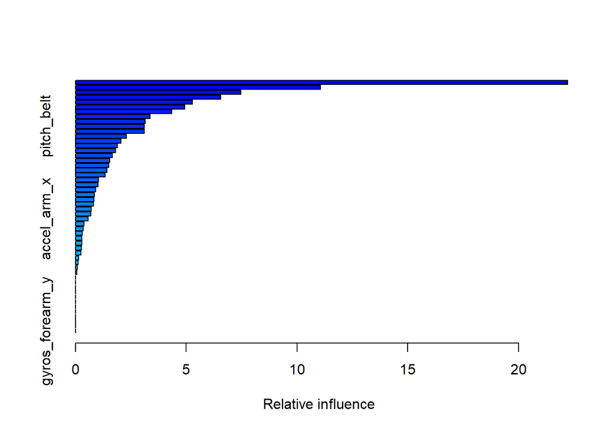

```
##                                       var     rel.inf
## roll_belt                       roll_belt 22.20897508
## pitch_forearm               pitch_forearm 11.06047489
## yaw_belt                         yaw_belt  7.46687557
## magnet_dumbbell_z       magnet_dumbbell_z  6.55958578
## magnet_dumbbell_y       magnet_dumbbell_y  5.27624083
## roll_forearm                 roll_forearm  4.92347342
## magnet_belt_z               magnet_belt_z  4.34764163
## accel_forearm_x           accel_forearm_x  3.37445126
## gyros_belt_z                 gyros_belt_z  3.13804565
## pitch_belt                     pitch_belt  3.09936278
## roll_dumbbell               roll_dumbbell  3.09903827
## accel_forearm_z           accel_forearm_z  2.30007794
## gyros_dumbbell_y         gyros_dumbbell_y  2.04537518
## accel_dumbbell_x         accel_dumbbell_x  1.89635569
## magnet_dumbbell_x       magnet_dumbbell_x  1.80429701
## yaw_arm                           yaw_arm  1.65970194
## magnet_arm_z                 magnet_arm_z  1.53561761
## magnet_forearm_z         magnet_forearm_z  1.50089541
## magnet_belt_y               magnet_belt_y  1.41886181
## accel_dumbbell_y         accel_dumbbell_y  1.33373750
## accel_dumbbell_z         accel_dumbbell_z  1.04086647
## magnet_arm_x                 magnet_arm_x  1.00717106
## magnet_forearm_x         magnet_forearm_x  0.91327888
## total_accel_dumbbell total_accel_dumbbell  0.85414815
## magnet_belt_x               magnet_belt_x  0.82386249
## magnet_arm_y                 magnet_arm_y  0.82361815
## gyros_arm_y                   gyros_arm_y  0.70639092
## roll_arm                         roll_arm  0.68553655
## accel_arm_x                   accel_arm_x  0.56626821
## gyros_forearm_z           gyros_forearm_z  0.39101365
## gyros_dumbbell_x         gyros_dumbbell_x  0.33802356
## accel_belt_z                 accel_belt_z  0.30288818
## gyros_belt_y                 gyros_belt_y  0.29272269
## accel_forearm_y           accel_forearm_y  0.28266583
## total_accel_forearm   total_accel_forearm  0.26246950
## accel_arm_z                   accel_arm_z  0.24365005
## magnet_forearm_y         magnet_forearm_y  0.14378185
## pitch_dumbbell             pitch_dumbbell  0.12470021
## gyros_dumbbell_z         gyros_dumbbell_z  0.07902206
## gyros_belt_x                 gyros_belt_x  0.06883629
## total_accel_belt         total_accel_belt  0.00000000
## accel_belt_x                 accel_belt_x  0.00000000
## accel_belt_y                 accel_belt_y  0.00000000
## pitch_arm                       pitch_arm  0.00000000
## total_accel_arm           total_accel_arm  0.00000000
## gyros_arm_x                   gyros_arm_x  0.00000000
## gyros_arm_z                   gyros_arm_z  0.00000000
## accel_arm_y                   accel_arm_y  0.00000000
## yaw_dumbbell                 yaw_dumbbell  0.00000000
## yaw_forearm                   yaw_forearm  0.00000000
## gyros_forearm_x           gyros_forearm_x  0.00000000
## gyros_forearm_y           gyros_forearm_y  0.00000000
```

```r
# from GBM
summary(modGBM)
```

```r
# from LDA
varImp(modLDA)
```

```
## ROC curve variable importance
##
##   variables are sorted by maximum importance across the classes
##   only 20 most important variables shown (out of 52)
##
##                        A       B     C      D       E
## pitch_forearm     63.914 100.000 67.63 63.914 100.000
## accel_forearm_x   39.427  80.049 39.43 39.427  80.049
## magnet_arm_y      39.562  78.749 67.73 39.562  78.749
## magnet_arm_x      53.676  78.566 65.39 53.676  78.566
## accel_arm_x       52.885  75.086 61.82 52.885  75.086
## pitch_dumbbell    52.248  52.248 52.25 72.234  45.132
## magnet_belt_y     17.263  14.907 69.01 14.907  17.263
## magnet_forearm_x  39.212  68.532 36.33 33.765  68.532
## magnet_dumbbell_x 63.476  63.476 63.48 63.592  51.351
## magnet_dumbbell_y 43.895  39.957 39.96 60.066  43.895
## roll_dumbbell     42.439  47.492 25.37 59.341  47.492
## magnet_dumbbell_z 58.887  37.242 53.34 23.992  58.887
## accel_dumbbell_x  56.209  56.209 56.21 57.203  49.835
## magnet_arm_z      53.317  53.317 53.32 53.317  39.580
## magnet_belt_z      2.713   1.861 50.77  1.861   2.713
## pitch_arm         27.513  41.250 48.61 27.513  41.250
## roll_belt         10.764   8.841 47.16  8.841  10.764
## accel_dumbbell_z  45.009  45.009 45.01 45.009  21.822
## yaw_dumbbell      21.039  21.039 21.04 42.395  12.597
## accel_belt_z      18.213  18.213 41.98 18.213  16.376
```

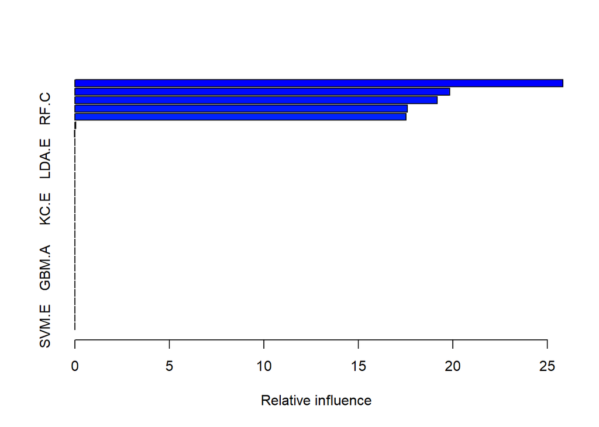

```
##         var      rel.inf
## RF.A   RF.A 2.581445e+01
## RF.B   RF.B 1.983523e+01
## RF.E   RF.E 1.916017e+01
## RF.C   RF.C 1.759326e+01
## RF.D   RF.D 1.752633e+01
## GBM.D GBM.D 4.290959e-02
## LDA.C LDA.C 1.401988e-02
## LDA.A LDA.A 1.045883e-02
## LDA.D LDA.D 1.169063e-03
## LDA.E LDA.E 8.292431e-04
## KC.A   KC.A 8.181017e-04
## GBM.E GBM.E 3.596779e-04
## KC.B   KC.B 0.000000e+00
## KC.C   KC.C 0.000000e+00
## KC.D   KC.D 0.000000e+00
## KC.E   KC.E 0.000000e+00
## LDA.B LDA.B 0.000000e+00
## ELM.A ELM.A 0.000000e+00
## ELM.B ELM.B 0.000000e+00
## ELM.C ELM.C 0.000000e+00
## ELM.D ELM.D 0.000000e+00
## ELM.E ELM.E 0.000000e+00
## GBM.A GBM.A 0.000000e+00
## GBM.B GBM.B 0.000000e+00
## GBM.C GBM.C 0.000000e+00
## SVM.A SVM.A 0.000000e+00
## SVM.B SVM.B 0.000000e+00
## SVM.C SVM.C 0.000000e+00
## SVM.D SVM.D 0.000000e+00
## SVM.E SVM.E 0.000000e+00
```

```r
# from GBM used for Stacking
summary(modSTK)
```

### Step 8 - Graphical Output

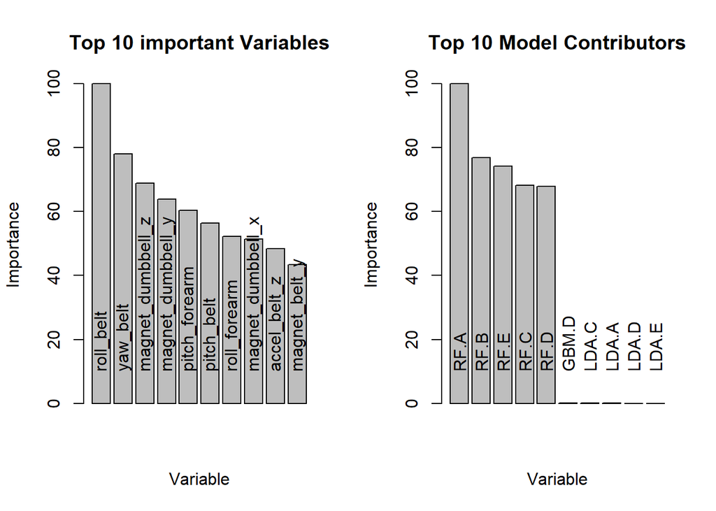

```r
# Let's see how we did graphically

par(mfrow=c(1,2))
# Variable importance from RF Model
imps <- varImp(modRF)$importance
imps$varname <- row.names(imps)
imps <-  imps[order(-imps$Overall),]
imps_top <- imps[1:10,]
barplot(imps_top$Overall,names.arg=row.names(imps_top), ylab="Importance",
        xlab="Variable",
        main="Top 10 important Variables", xaxt="n")
text(x=seq(1:10)*1.2-.5, y=10,
     labels=row.names(imps_top), srt=90, adj=0, xpd=TRUE)

imps <- varImp(modSTK)$importance
imps$varname <- row.names(imps)
imps <-  imps[order(-imps$Overall),]
imps_top <- imps[1:10,]
barplot(imps_top$Overall,names.arg=row.names(imps_top), ylab="Importance",
        xlab="Variable",
        main="Top 10 Model Contributors", xaxt="n")
text(x=seq(1:10)*1.2-.5, y=10,
     labels=row.names(imps_top), srt=90, adj=0, xpd=TRUE)
```

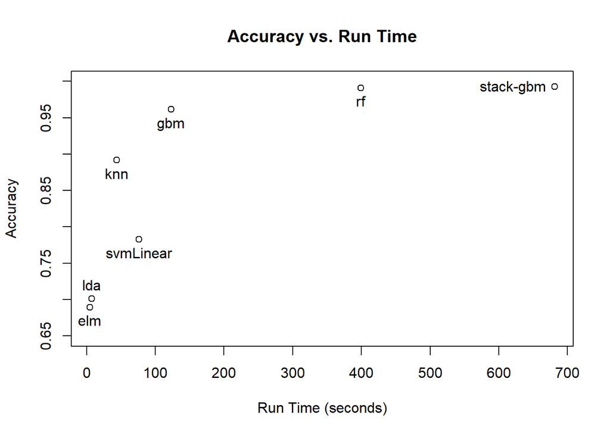

```r
# Plot Accuracy vs. Time to Run
par(mfrow=c(1,1))
plot(m_accuracy~run_time,
     xlab = 'Run Time (seconds)',
     ylab = 'Accuracy', main = 'Accuracy vs. Run Time', ylim=c(.65,1.00),
     data = m_comparisons)
with(m_comparisons, text(m_accuracy~run_time,
            labels = model_type, pos = c(1,1,3,1,1,1,2)))
```

## Conclusions

It appears that we can create a model that predicts with >99% certainty (less than 1% error) outside of the training sample …. at least for these test subjects. I suspect we might have more error with different test subjects that have their own idosyncracies in how they perform the exercise.

From our various results we can see that the stacked GBM ensemble model was the best and had over 99% accuracy and kappa, but took the longest to run. The Random forest algorithm was almost as good and took half as much time to run. The accuracy/efficiency inflection seemed to be the GBM algorithm that achieved accuracy of 95% in a little over two minutes to run.